# Conceptos básicos de imágenes

## 1 Introducción

Antes de aplicar filtros, detectar bordes o segmentar objetos, es útil entender cómo ve una computadora una imagen. Desde el punto de vista computacional, una imagen no es un dibujo sino una matriz de números.

En esta sesión trabajaremos con conceptos fundamentales:

- píxel
- resolución
- canales
- imagen en escala de grises
- imagen en color
- tipo de dato
- conversión entre formatos

## 2 1. Imagen como matriz

Una imagen digital se representa como una matriz tridimensional:

- filas: alto
- columnas: ancho
- canales: información por píxel

Por ejemplo, una imagen en color suele tener forma:

$$(h, w, 3)$$

donde:

- $h$ = altura
- $w$ = ancho
- $3$ = canales RGB (o BGR en OpenCV)

En escala de grises, la forma es:

$$(h, w)$$

## 3 2. Píxel

Un píxel es la unidad mínima de una imagen. Cada píxel tiene un valor numérico que representa su intensidad o color.

En una imagen en escala de grises, cada píxel tiene un solo valor entre 0 y 255.

En una imagen en color, cada píxel tiene tres valores:

- rojo (R)
- verde (G)
- azul (B)

En OpenCV, los canales se almacenan como BGR, no como RGB, por lo que al mostrarlos con Matplotlib suele ser necesario convertirlos.

## 4 3. Canales de una imagen

Una imagen color puede descomponerse en sus canales:

- canal B: azul
- canal G: verde
- canal R: rojo

Esto permite trabajar con cada componente por separado y comprender cómo aporta información a la imagen.

## 5 4. Escala de grises

Una imagen en escala de grises contiene un solo canal. Cada píxel indica solamente el nivel de brillo.

Ejemplo: 0 representa negro y 255 representa blanco.

## 6 5. Formas y tipos de datos

Cuando cargamos una imagen con OpenCV, podemos inspeccionar:

- `img.shape`: dimensiones de la imagen
- `img.dtype`: tipo de dato (por ejemplo `uint8`)
- `img.min()` y `img.max()`: valores mínimo y máximo

En muchas imágenes, el tipo más común es `uint8`, es decir, enteros sin signo de 8 bits.

## 7 6. Ejemplo práctico con OpenCV

```
Forma: (670, 1072, 3)
Tipo: uint8
Minimo: 0
Maximo: 255
```

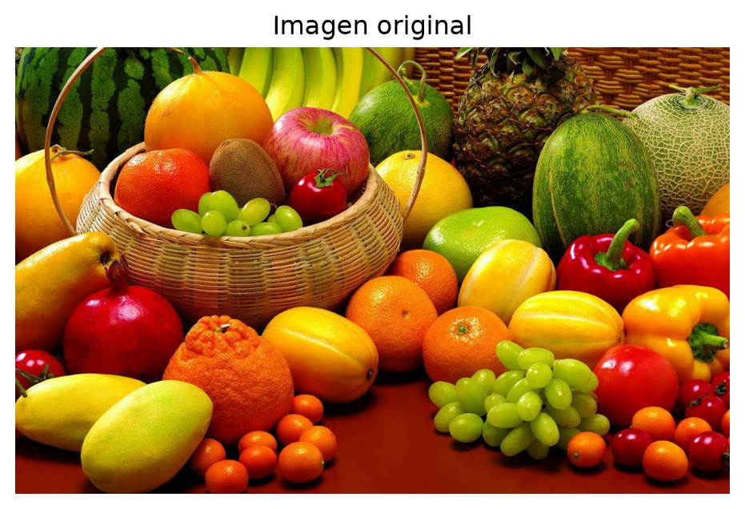

```python
import cv2
import numpy as np
import matplotlib.pyplot as plt
from pathlib import Path

ruta = Path("imagenes") / "frutas.jpg"
img = cv2.imread(str(ruta))

if img is None:
    raise FileNotFoundError(f"No se encontró la imagen: {ruta}")

print("Forma:", img.shape)
print("Tipo:", img.dtype)
print("Minimo:", img.min())
print("Maximo:", img.max())

plt.figure(figsize=(6,6))
plt.imshow(cv2.cvtColor(img, cv2.COLOR_BGR2RGB))
plt.title("Imagen original")
plt.axis("off")
plt.show()
```

## 8 7. Acceso a píxeles

Podemos acceder a un píxel concreto usando sus coordenadas `(fila, columna)`.

```python
pixel = img[100, 150]
print("Valores del píxel (fila 100, columna 150):", pixel)
```

```
Valores del píxel (fila 100, columna 150): [ 8 13 12]
```

En imágenes en color, el píxel devuelve tres números: B, G y R.

## 9 8. Separación de canales

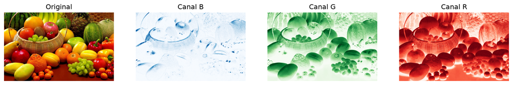

```python
b, g, r = cv2.split(img)

fig, axes = plt.subplots(1, 4, figsize=(16, 4))

axes[0].imshow(cv2.cvtColor(img, cv2.COLOR_BGR2RGB))
axes[0].set_title("Original")
axes[0].axis("off")

axes[1].imshow(b, cmap="Blues")
axes[1].set_title("Canal B")
axes[1].axis("off")

axes[2].imshow(g, cmap="Greens")
axes[2].set_title("Canal G")
axes[2].axis("off")

axes[3].imshow(r, cmap="Reds")
axes[3].set_title("Canal R")
axes[3].axis("off")

plt.show()
```

¿Qué observas? Cada canal resalta una parte de la imagen. Por ejemplo, el canal rojo hace que las zonas rojas se vean más intensas.

## 10 9. Conversión a escala de grises

```
Forma en grises: (670, 1072)
```

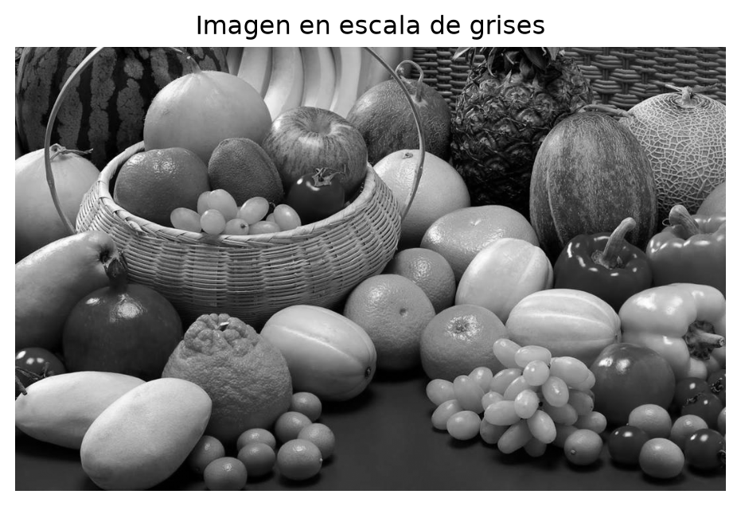

```python
gray = cv2.cvtColor(img, cv2.COLOR_BGR2GRAY)
print("Forma en grises:", gray.shape)

plt.figure(figsize=(6, 6))
plt.imshow(gray, cmap="gray")
plt.title("Imagen en escala de grises")
plt.axis("off")
plt.show()
```

La imagen en escala de grises pierde información de color, pero conserva la información de intensidad de brillo.